# Election Prediction

### Read required data

```r
polling <- read.csv("data/PollingData.csv")
glimpse(polling)

table(polling$Year)

summary(polling)
# we have missing values for Rasmussen and SurveyUSA
```

[output not shown]

### Handle missing values.

##### Multiple Imputation can be used to impute the missing values

```r
summary(polling)
```

```
         State          Year        Rasmussen         SurveyUSA         DiffCount           PropR          Republican
 Arizona    :  3   Min.   :2004   Min.   :-41.000   Min.   :-33.000   Min.   :-19.000   Min.   :0.0000   Min.   :0.0000
 Arkansas   :  3   1st Qu.:2004   1st Qu.: -8.000   1st Qu.:-11.000   1st Qu.: -6.000   1st Qu.:0.0000   1st Qu.:0.0000
 California :  3   Median :2008   Median :  3.000   Median :  1.000   Median :  1.000   Median :0.6250   Median :1.0000
 Colorado   :  3   Mean   :2008   Mean   :  1.731   Mean   :  1.517   Mean   : -1.269   Mean   :0.5259   Mean   :0.5103
 Connecticut:  3   3rd Qu.:2012   3rd Qu.: 11.000   3rd Qu.: 18.000   3rd Qu.:  4.000   3rd Qu.:1.0000   3rd Qu.:1.0000
 Florida    :  3   Max.   :2012   Max.   : 39.000   Max.   : 30.000   Max.   : 11.000   Max.   :1.0000   Max.   :1.0000
 (Other)    :127
```

### Distribute the data into Train and Test sets

```r
table(train$Republican)
```

```
 0  1
47 53
```

#### Understand the prediction of Baseline model against which any Model that we create will be compared. To do that, look at the breakdown of dependent variable in the training set using table()

In 47 of 100 obs., Democrat won the state, and Republican in 53. Baseline is always going to predict the most common output, so, it will have Republican win the State with the accuracy of 53%.

But it is quite a weak model, since it will alwasy favor Republican and that too for a very weak accuracy.

To find a Smarter Baseline model, which will be to take one of the State observation, and predict the winner. To compute this, we’ll use a sign() which returns 1 if it is passed a +ve number, -1 for -ve and a 0 for Zero.

```r
table(sign(train$Rasmussen))
```

```
-1  0  1
42  3 55
```

HOw does the Baseline compare with the actual model.

```r
table(train$Republican, sign(train$Rasmussen))
```

```
    -1  0  1
  0 42  2  3
  1  0  1 52
```

This seems to be a much better Model to carry forward against which we can compare the Logistic Regression based approach.

#### Find out the correlation matrix:

```r
cor(train[c("Rasmussen", "SurveyUSA", "PropR", "DiffCount", "Republican")])
```

```
           Rasmussen SurveyUSA     PropR DiffCount Republican
Rasmussen  1.0000000 0.9194508 0.8404803 0.5124098  0.8021191
SurveyUSA  0.9194508 1.0000000 0.8756581 0.5541816  0.8205806
PropR      0.8404803 0.8756581 1.0000000 0.8273785  0.9484204
DiffCount  0.5124098 0.5541816 0.8273785 1.0000000  0.8092777
Republican 0.8021191 0.8205806 0.9484204 0.8092777  1.0000000
```

SurveyUSA ~ Rasmussen -> 0.91

The variables in a model will be the ones most related to dependent variable.

### Fit a model

```r
table(train$Republican, pred1 >= 0.5)
```

```
    FALSE TRUE
  0    45    2
  1     2   51
```

### Try another model

```r
summary(mod2)
```

```
Call:
glm(formula = Republican ~ SurveyUSA + DiffCount, family = binomial,
    data = train)

Deviance Residuals:
     Min        1Q    Median        3Q       Max
-2.01196  -0.00698   0.01005   0.05074   1.54975

Coefficients:
            Estimate Std. Error z value Pr(>|z|)
(Intercept)  -1.1405     1.2456  -0.916   0.3599
SurveyUSA     0.2976     0.1949   1.527   0.1267
DiffCount     0.7673     0.4188   1.832   0.0669 .
---
Signif. codes:  0 â€˜***â€™ 0.001 â€˜**â€™ 0.01 â€˜*â€™ 0.05 â€˜.â€™ 0.1 â€˜ â€™ 1

(Dispersion parameter for binomial family taken to be 1)

    Null deviance: 138.269  on 99  degrees of freedom
Residual deviance:  12.439  on 97  degrees of freedom
AIC: 18.439

Number of Fisher Scoring iterations: 10
```

```r
table(test$Republican, sign(test$Rasmussen))
```

```
    -1  0  1
  0 18  2  4
  1  0  0 21
```

18 - Smart baseline predicted correctly for Democratic, and was correct. 21- Smart baseline predicted correctly for Republican, and was correct. 2- Inconclusive.

4- Mistakes

So, this the model we’ll compare our final model against.

```r
table(test$Republican, testPred > 0.5)
```

```
    FALSE TRUE
  0    23    1
  1     0   21
```

Accuracy Error =1

|  | State | Year | Rasmussen | SurveyUSA | DiffCount | PropR | Republican |
| --- | --- | --- | --- | --- | --- | --- | --- |
| 24 | Florida | 2012 | 2 | 0 | 6 | 0.6666667 | 0 |

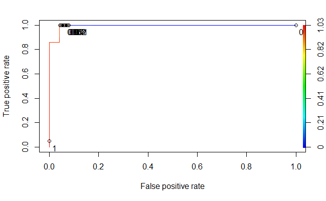